# Loan Default Prediction Algorithm

## Steps in CRISP-DM (Cross Industry Standard Process for Data Mining )

Step 1: Understand the Business Objective/Question  
Step 2: Data Understanding  
Step 3: Data Preparation  
Step 4: Modeling  
Step 5: Evaluation  
Step 6: Deployment

# Step 1: Understand the Business Question

The Business question that this project seeks to answer is whether an individual that has a loan will default and the probability that the individual may default.

## Special Business Use Case

Know the probability that a bank customer has of defaulting can be helpful to bankers when trying to set interest rates, because they will have a better idea of the risk involved with writing loans to each individual customer.

# Step 2: Data Understanding

The following are the variables in our dataset that we must deploy in our classification model

## **Data Dictionary**

### **Dependent Variable**

**Loan Status:** **Categorical variable**  
that expresses if the loan was paid back or defaulted

### **Independent Variables**

**Current Loan Amount:** **Numeric variable**  
that represents the amount of the loan that was paid of fully or defaulted  
**Term:** **Categorical variable**  
indicating the length of the loan  
**Credit Score:** **Numeric variable**  
representing the riskiness of the customer  
**Years in current job:** **Ordinal variable**  
that represents the amount of time the customer has spent in their current job  
**Home Ownership:** **Categorical variable**  
that indicates whether the customer rents, has a mortgage or completely owns their home  
**Annual Income:** **Numeric variable**  
representing the annual income of the customer  
**Purpose:** **Categorical variable**  
representing why the customer wants the loan  
**Monthly Debt :** **Numeric variable**  
representing monthly debt of the customer  
**Years of Credit History:** **Numeric variable**  
representing years since the first entry into the customer’s credit history  
**Months since last delinquent:** **Numeric variable**  
representing time since the customers last loan delinquent payment  
**Number of Open Accounts:** **Numeric variable**  
representing the number of credit cards the customer currently has  
**Number of Credit Problems:** **Numeric variable**  
representing the number of credit problems in the customer's history  
**Current Credit Balance:** **Numeric variable**  
representing the current total debt of the customer  
**Maximum Open Credit:** **Numeric variable**  
representing the max credit from all credit sources that the customer has  
**Bankruptcies:** **Numeric variable**  
representing the number of bankruptcies of customer  
**Tax Liens:** **Numeric variable**  
representing the number of Tax Liens of customer

### **Descriptive Variables**

**Loan ID:** Used to identify a specific loan; each is unique  
**Customer ID:** Used to identify a specific customer; may occur multiple times for multiple loans

# Step 3: Data Preparation

## Begin by Downloading necessary libraries and reading necessary files into Data frames

```python
import pandas as pd
import numpy as np
import matplotlib.pyplot as plt
%matplotlib inline
df=pd.read_csv('LoansTrainingSet.csv')
```

```python
df.info()
```

```
<class 'pandas.core.frame.DataFrame'>
RangeIndex: 256984 entries, 0 to 256983
Data columns (total 19 columns):
Loan ID                         256984 non-null object
Customer ID                     256984 non-null object
Loan Status                     256984 non-null object
Current Loan Amount             256984 non-null int64
Term                            256984 non-null object
Credit Score                    195308 non-null float64
Years in current job            256984 non-null object
Home Ownership                  256984 non-null object
Annual Income                   195308 non-null float64
Purpose                         256984 non-null object
Monthly Debt                    256984 non-null object
Years of Credit History         256984 non-null float64
Months since last delinquent    116601 non-null float64
Number of Open Accounts         256984 non-null int64
Number of Credit Problems       256984 non-null int64
Current Credit Balance          256984 non-null int64
Maximum Open Credit             256984 non-null object
Bankruptcies                    256455 non-null float64
Tax Liens                       256961 non-null float64
dtypes: float64(6), int64(4), object(9)
memory usage: 37.3+ MB
```

## Step 3a: Clean the Data

## Remove Outliers

### Credit Score Outliers

Credit Score should be between 0-900

```python
# Check for numbers outside the range 0-900
dfover=[]
for row in df['Credit Score']:
    if row>900:
        dfover.append(row)
dfover[:10]
```

```
[6640.0,
 7320.0,
 7180.0,
 6670.0,
 7270.0,
 7070.0,
 7370.0,
 7060.0,
 7410.0,
 7330.0]
```

It appears that all the outliers have been entered with an extra 0. To fix this we will create a loop to remove the extra 0

```python
# Remove Outliers outside of range 0-800
realnums=[]
for row in df['Credit Score']:
    if row>900:
        real=row/10
        realnums.append(real)
    else:
        realnums.append(row)

df['Credit Score']=realnums
df['Credit Score'].max()
```

```
751.0
```

### Current Loan Amount Outliers

plot the Current loan amount column as a histogram to check for outliers

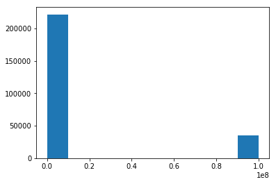

```python
plt.hist(df['Current Loan Amount'])
```

Another way to check for outliers is to look at the mean vs median

```python
print df['Current Loan Amount'].mean()
print df['Current Loan Amount'].median()
```

```
13713306.2602
14298.0
```

when the mean is much larger than the median it indicates that the data is skewed right

Now let’s look at what and where the outliers are

```python
greater_than_mean = df['Current Loan Amount'] > df['Current Loan Amount'].mean()
df[greater_than_mean].head(5)
```

|  | Loan ID | Customer ID | Loan Status | Current Loan Amount | Term | Credit Score | Years in current job | Home Ownership | Annual Income | Purpose | Monthly Debt | Years of Credit History | Months since last delinquent | Number of Open Accounts | Number of Credit Problems | Current Credit Balance | Maximum Open Credit | Bankruptcies | Tax Liens |
| --- | --- | --- | --- | --- | --- | --- | --- | --- | --- | --- | --- | --- | --- | --- | --- | --- | --- | --- | --- |
| 10 | 00020fb0-6b8a-4b3a-8c72-9c4c847e8cb6 | c9decd06-16f7-44c3-b007-8776f2a9233d | Fully Paid | 99999999 | Short Term | 742.0 | 3 years | Home Mortgage | 64760.0 | Debt Consolidation | $582.84 | 26.8 | NaN | 11 | 0 | 8880 | 22711 | 0.0 | 0.0 |
| 16 | 0002c691-5314-44ab-b205-3fb1cc4ee6b2 | 41207d1e-5d13-43ec-9fe9-f222b4da5e0c | Fully Paid | 99999999 | Short Term | 744.0 | 6 years | Home Mortgage | 65605.0 | Debt Consolidation | $984.07 | 21.0 | NaN | 5 | 1 | 11514 | 17262 | 1.0 | 0.0 |
| 23 | 0003fbfd-33ee-4ae9-8074-b46f6ff59281 | c14bbc84-5041-4e70-bd64-3db51f7e80ae | Fully Paid | 99999999 | Short Term | 745.0 | 10+ years | Rent | 39476.0 | other | $483.58 | 15.4 | 79.0 | 12 | 0 | 4636 | 21171 | 0.0 | 0.0 |
| 28 | 0004f37b-5859-40f6-98d0-367aa3b3f3f1 | f662b062-5fa5-463d-b5c0-4e36d09fcab1 | Fully Paid | 99999999 | Short Term | 724.0 | 1 year | Own Home | 34297.0 | Home Improvements | $777.38 | 13.6 | 2.0 | 12 | 0 | 6720 | 53335 | 0.0 | 0.0 |
| 42 | 0008cacc-1ea9-4599-b114-12709b13c85d | cd853967-4535-4d36-bf93-269504c74911 | Fully Paid | 99999999 | Short Term | 750.0 | 10+ years | Own Home | 86785.0 | Other | $56.41 | 22.0 | NaN | 7 | 0 | 3959 | 63862 | 0.0 | 0.0 |

Now let’s replace the wrong numbers with the median value

```python
median=df['Current Loan Amount'].median()
quantile95 = df['Current Loan Amount'].quantile(.95)
df['Current Loan Amount']=df['Current Loan Amount'].map(lambda x: median if x>=quantile95 else x)
```

Now let’s look at the distribution again

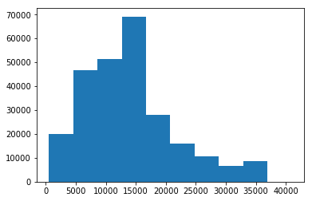

```python
plt.hist(df['Current Loan Amount']);
```

### Duplicates

check for duplicate customer ID's and Loan ID's

```python
# All loans Id's are unique so there should be no duplicates

print 'there should be', len(df['Loan ID']), 'but there are only', df['Loan ID'].nunique()
```

```
there should be 256984 but there are only 215700
```

We must find and get rid of the duplicates while keeping the relevant data

```python
df=df.groupby(df['Loan ID']).max()
```

```python
# Check to see if customers have taken out multiple loans by checking for duplicate Customer ID's

print  len(df['Loan ID']), 'should be equal to', df['Loan ID'].nunique() , 'if there are no duplicates'
```

```
215700 should be equal to 215700 if there are no duplicates
```

## Step 3b: Fill in the null values

1) Months since last delinquent  
2) Bankruptcies  
3) Tax Liens

### Months since last delinquent null Values

Check to see if There are 0 values otherwise nan may indicate no past history or 0 delinquent payments

```python
for row in df['Months since last delinquent']:
    if row==0:
        print 'We have a 0'
        break
```

```
We have a 0
```

Look at where there are 0s in the Months since last delinquent column for patterns

```python
indexlist=[]
s=0
for row in df['Months since last delinquent']:
    if row==0:
        indexlist.append(s)
    s+=1

df.ix[indexlist].head(5)
```

| Loan ID | Loan ID | Customer ID | Loan Status | Current Loan Amount | Term | Credit Score | Years in current job | Home Ownership | Annual Income | Purpose | Monthly Debt | Years of Credit History | Months since last delinquent | Number of Open Accounts | Number of Credit Problems | Current Credit Balance | Maximum Open Credit | Bankruptcies | Tax Liens |
| --- | --- | --- | --- | --- | --- | --- | --- | --- | --- | --- | --- | --- | --- | --- | --- | --- | --- | --- | --- |
| 001eb42c-2b5b-4640-bf9d-8c086a1076f4 | 001eb42c-2b5b-4640-bf9d-8c086a1076f4 | 9377bba7-2cab-4478-91c2-a3ff2904638d | Fully Paid | 12128.0 | Short Term | 747.0 | 7 years | Home Mortgage | 90963.0 | Debt Consolidation | $123.56 | 24.1 | 0.0 | 6 | 0 | 4406 | 28795 | NaN | 0.0 |
| 002dc37f-f6b5-4113-8d5c-53c25ac6111e | 002dc37f-f6b5-4113-8d5c-53c25ac6111e | 647fd091-0705-4a01-9da6-e57c427562f0 | Fully Paid | 5006.0 | Short Term | 749.0 | < 1 year | Own Home | 45054.0 | Debt Consolidation | $42.05 | 25.0 | 0.0 | 5 | 0 | 1785 | 0 | NaN | NaN |
| 003a3241-adbe-4337-b73a-5085c6834a74 | 003a3241-adbe-4337-b73a-5085c6834a74 | 08117601-9319-41e3-9fa6-6da917c70fa5 | Charged Off | 7253.0 | Short Term | 744.0 | < 1 year | Rent | 45329.0 | Debt Consolidation | $30.22 | 15.9 | 0.0 | 4 | 0 | 3356 | 10968 | NaN | 0.0 |
| 00603463-baa7-403d-ae74-752eee57d711 | 00603463-baa7-403d-ae74-752eee57d711 | 45fbec08-da53-44c1-a196-be3c6e794028 | Fully Paid | 8301.0 | Short Term | 747.0 | 9 years | Home Mortgage | 49157.0 | other | $405.13 | 35.8 | 0.0 | 14 | 0 | 7769 | 45432 | NaN | 0.0 |
| 00f848f9-0122-42a8-9386-88e28ecc9408 | 00f848f9-0122-42a8-9386-88e28ecc9408 | 2a326063-9fcf-40fa-af0f-a9339c6de96b | Fully Paid | 6918.0 | Short Term | 740.0 | 10+ years | Own Home | 96853.0 | Debt Consolidation | $2,146.91 | 41.2 | 0.0 | 13 | 0 | 12352 | 34598 | 0.0 | 0.0 |

We can also look at the null values to see if there are a lot of credit Problems

```python
indexlist=[]
s=0
for row in df['Months since last delinquent']:
    if pd.isnull(row):
        indexlist.append(s)
    s+=1

df.ix[indexlist].head(5)
```

| Loan ID | Loan ID | Customer ID | Loan Status | Current Loan Amount | Term | Credit Score | Years in current job | Home Ownership | Annual Income | Purpose | Monthly Debt | Years of Credit History | Months since last delinquent | Number of Open Accounts | Number of Credit Problems | Current Credit Balance | Maximum Open Credit | Bankruptcies | Tax Liens |
| --- | --- | --- | --- | --- | --- | --- | --- | --- | --- | --- | --- | --- | --- | --- | --- | --- | --- | --- | --- |
| 00002c49-3a29-4bd4-8f67-c8f8fbc1048c | 00002c49-3a29-4bd4-8f67-c8f8fbc1048c | 927b388d-2e01-423f-a8dc-f7e42d668f46 | Fully Paid | 3441.0 | Short Term | 734.0 | 4 years | Home Mortgage | 42269.0 | other | $1,106.04 | 26.3 | NaN | 17 | 0 | 6262 | 19149 | 0.0 | 0.0 |
| 00002d89-27f3-409b-aa76-90834f359a65 | 00002d89-27f3-409b-aa76-90834f359a65 | defce609-c631-447d-aad6-1270615e89c4 | Fully Paid | 21029.0 | Short Term | 747.0 | 10+ years | Home Mortgage | 90126.0 | Debt Consolidation | $1,321.85 | 28.8 | NaN | 5 | 0 | 20967 | 28335 | 0.0 | 0.0 |
| 00005222-b4d8-45a4-ad8c-186057e24233 | 00005222-b4d8-45a4-ad8c-186057e24233 | 070bcecb-aae7-4485-a26a-e0403e7bb6c5 | Fully Paid | 18743.0 | Short Term | 747.0 | 10+ years | Own Home | 38072.0 | Debt Consolidation | $751.92 | 26.2 | NaN | 9 | 0 | 22529 | 43915 | 0.0 | 0.0 |
| 0000757f-a121-41ed-b17b-162e76647c1f | 0000757f-a121-41ed-b17b-162e76647c1f | dde79588-12f0-4811-bab0-e2b07f633fcd | Fully Paid | 11731.0 | Short Term | 746.0 | 4 years | Rent | 50025.0 | Debt Consolidation | $355.18 | 11.5 | NaN | 12 | 0 | 17391 | 37081 | 0.0 | 0.0 |
| 0000a149-b055-4a57-b762-280783ccc25e | 0000a149-b055-4a57-b762-280783ccc25e | 62ddc017-7023-4ba7-af23-1a7cd16c1ce5 | Fully Paid | 10208.0 | Short Term | 716.0 | 10+ years | Rent | 41853.0 | Business Loan | $561.52 | 13.2 | NaN | 4 | 1 | 2289 | 4671 | 1.0 | 0.0 |

Looking at the Number in the column Credit Problems we see that they are mostly 0 so we might assume that 0 and null means that the customer has no past delinquent payments, because they have no Credit Problems, but with using industry knowledge we know that a 0 does in fact mean that the customer just missed a payment.

Now in order to show that the customers with null values have never missed a payment we must convert this variable into a categorical variable by binning the numbers into categories that make sense

```python
# convert int months into categorical variables
# convert NaN values into category 'no past history'

# create bins out of the different time periods and store each instance in new list
newlist=[]
for row in df['Months since last delinquent']:
    if  row<=3:
        n = 'less than 3 months'
        newlist.append(n)
    elif 3<row and row<=6:
        n = 'Over 3 months'
        newlist.append(n)
    elif 6<row and row<=12:
        n = 'over half a year'
        newlist.append(n)
    elif 12<row and row<=24:
        n = 'Over a year'
        newlist.append(n)
    elif 24<row:
        n = 'Over 2 years'
        newlist.append(n)
    else:
        n= 'no past history'
        newlist.append(n)

# assign new list to the column
df['Months since last delinquent']=newlist
```

### Tax Liens null Values

Find the number of null values in the tax Liens column

```python
df['Tax Liens'].isnull().sum()
```

```
22
```

Because there are only a few null values fill in the Null Values with the mode

```python
TaxLiens_mode=df['Tax Liens'].mode()

print TaxLiens_mode

df['Tax Liens'].fillna(0,inplace=True)
```

```
0    0.0
dtype: float64
```

### Bankruptcies null Values

```python
df['Tax Liens'].isnull().sum()
```

```
0
```

```python
Bankruptcies_mode=df['Bankruptcies'].mode()

print Bankruptcies_mode

df['Bankruptcies'].fillna(0,inplace=True)
```

```
0    0.0
dtype: float64
```

## Preprocessing

1) Monthly Debt  
2) Purpouse  
3) Maximum Open Credit

### Monthly Debt

Convert Monthly Debt column from an object to an int variable

```python
# loop stores characters with ascii values between 0 and 9 in a list then assigns that list to the column Monthly Debt
debtlist=[]
for row in df['Monthly Debt']:
    row=str(row)
    numlist=[]
    for nums in row:
        if nums>='0':
            if nums<='9':
                numlist.append(nums)
    numlist=numlist[0:-2]
    numlist="".join(numlist)
    numlist=int(numlist)
    debtlist.append(numlist)

df['Monthly Debt']=debtlist
```

### Purpouse

Check to ensure there are no duplicates in the purpose column

```python
# looks at all the unique values in the purpouse column
print df['Purpose'].unique()
```

```
['Debt Consolidation' 'other' 'Business Loan' 'Home Improvements'
 'Buy House' 'Other' 'Buy a Car' 'Medical Bills' 'Take a Trip'
 'Educational Expenses']
```

We see an error in that there are to instances of other each spelled differently. This must be fixed or else the algorithm will see these two instances of other as separate categorical variables.

```python
# function converts all instances of other into Other
df['Purpose']=df['Purpose'].map(lambda x: 'Other' if x=='other' else x)
print df['Purpose'].unique()
```

```
['Debt Consolidation' 'Other' 'Business Loan' 'Home Improvements'
 'Buy House' 'Buy a Car' 'Medical Bills' 'Take a Trip'
 'Educational Expenses']
```

### Maximum Open Credit

First we must convert all the non-integer values into integers

```python
# convert object variables into int variables
s=0
indexlist=[]
for row in df['Maximum Open Credit']:
    try:
        int(row)
    except ValueError:
        indexlist.append(s)
    s+=1
```

```python
df['Maximum Open Credit'][indexlist]=0
df['Maximum Open Credit']=df['Maximum Open Credit'].apply(lambda x: int(x))
```

Now that we have the index of all the non-int values which we gave a value of 0 we are going to fill in these values based of the customers number of Open Accounts

We will use the mean of maximum Open Credit as a value and the Number of Open accounts as the key in a dictionary that will be applied to the 0 values we found above

```python
# find the mean for each instance of Number of open Accounts
# i.e. what is the mean maximum open credit for all customers with 1 open account

df2=df.drop(df.index[indexlist])

dflist=pd.DataFrame()
dflist=df.groupby('Number of Open Accounts')['Maximum Open Credit'].mean()
df3=pd.DataFrame(dflist)
```

Now that we have the mean value for each instance of number of open accounts we will store each instance of number of open accounts in a list and combine it with the list of means to create a dictionary

```python
# Store the means and unique values of Number of Open Accounts in a list
Num_of_open_acc=df['Number of Open Accounts'].unique()
Num_of_open_acc.sort()
Max_open_credit_avg=df3['Maximum Open Credit']

# Create the dictionary of Number of Open Accounts as the key and the mean Maximum Open Credit as the value
max_credit_dict = {}

# fill the dictionary
Num_of_open_acc_and_Max_open_credit = zip(Num_of_open_acc, Max_open_credit_avg)
for Num_of_open_acc, Max_open_credit_avg in Num_of_open_acc_and_Max_open_credit:
    max_credit_dict[Num_of_open_acc] = Max_open_credit_avg
```

Now that we have the dictionary we will use the dictionary to fill in the values in the index positions we stored in a list above.

```python
# loop iterates through the index list applying the dictionary at each position
for i in indexlist:
    num=df.iloc[i]['Number of Open Accounts']
    df.iloc[i]['Maximum Open Credit']=max_credit_dict[num]
```

## Predicting Null Values

1) Credit Score  
2) Annual Income

### Credit Score null values

We will use an algorithm to predict the null values for credit score

First we must find which variables are good predictors of Credit Score by looking at the correlation of other variables

```python
# Looking at Credit Score Correlation
cor=df.corr()
cor[['Credit Score']]
```

|  | Credit Score |
| --- | --- |
| Current Loan Amount | -0.201107 |
| Credit Score | 1.000000 |
| Annual Income | 0.014844 |
| Monthly Debt | -0.088166 |
| Years of Credit History | 0.085461 |
| Number of Open Accounts | -0.038642 |
| Number of Credit Problems | -0.062030 |
| Current Credit Balance | -0.014965 |
| Maximum Open Credit | 0.010204 |
| Bankruptcies | -0.048236 |
| Tax Liens | -0.027479 |

Now we create a list of all the rows where the values of Credit Score is null so that we may later predict the credit score for these rows

```python
# loop that stores row number of null values of credit score in indexlist
s=0
indexlist=[]
for row in df['Credit Score']:
    try:
        int(row)
    except ValueError:
        indexlist.append(s)
    s+=1
```

Now we store the rows of with null values for credit score in them in our x_test and remove columns we don't want in our algorithm

```python
x_test=df.iloc[indexlist]
x_test=x_test[['Current Loan Amount','Monthly Debt','Years of Credit History','Current Credit Balance']]
```

Next we drop any null values

```python
x_test.dropna(inplace=True)
```

Finally we create our y_train variable and drop all the missing values with a dropna function and assign our x and y variables

```python
df_train=df.copy()

df_train.dropna(inplace=True)

X_train=df_train[['Current Loan Amount','Monthly Debt','Years of Credit History','Current Credit Balance']]
y_train=df_train[['Credit Score']]
```

Now that we have our x and y variables we import necessary libraries and create and fit the model

```python
from sklearn import linear_model
from sklearn.linear_model import Ridge

creditreg= linear_model.Ridge()
creditreg.fit(X_train, y_train)
```

```
Ridge(alpha=1.0, copy_X=True, fit_intercept=True, max_iter=None,
   normalize=False, random_state=None, solver='auto', tol=0.001)
```

Next we predict the null values using our model

```python
y_pred_credit=creditreg.predict(x_test)
```

Finally we assign the predicted values back into the data frame at their respective positions

```python
# loop assigns predicted credit scores from list to each null value in the column Credit Score
i=0
for index, row in df.iterrows():
    if(pd.isnull(row['Credit Score'])):
        df.at[index,'Credit Score']=y_pred_credit[i]
        i+=1
```

### Annual Income null values

Now we repeat the same process but with the Annual Income null values

```python
# Look at Annual Income Correlation
cor=df.corr()
cor[['Annual Income']]
```

|  | Annual Income |
| --- | --- |
| Current Loan Amount | 0.308833 |
| Credit Score | 0.014844 |
| Annual Income | 1.000000 |
| Monthly Debt | 0.471007 |
| Years of Credit History | 0.155115 |
| Number of Open Accounts | 0.145422 |
| Number of Credit Problems | -0.017196 |
| Current Credit Balance | 0.305022 |
| Maximum Open Credit | 0.031687 |
| Bankruptcies | -0.047194 |
| Tax Liens | 0.036210 |

Loop through Annual Income column find the rows with null values store them in a list use the list to create the x_test variable then remove columns that will not be used to predict Annual Income

```python
s=0
indexlist=[]
for row in df['Annual Income']:
    try:
        int(row)
    except ValueError:
        indexlist.append(s)
    s+=1

x_test=df.ix[indexlist]
x_test=x_test[['Current Loan Amount','Monthly Debt','Years of Credit History','Current Credit Balance']]
```

Finish assigning the x and y variables for the algorithm

```python
df_train=df.copy()

df_train.dropna(inplace=True)

X_train=df_train[['Current Loan Amount','Monthly Debt','Years of Credit History','Current Credit Balance']]
y_train=df_train[['Annual Income']]
```

create and fit the model then use the model to predict the null values

```python
# Creates the model using the Ridge algorithm
incomereg= linear_model.Ridge()
# Fits the model using our train data
incomereg.fit(X_train, y_train)
# Predicts the null values using our fitted model
y_pred_income=incomereg.predict(x_test)
```

Replace the null values with the predicted values stored in the list above

```python
i=0
for index, row in df.iterrows():
    if(pd.isnull(row['Annual Income'])):
        df.at[index,'Annual Income']=y_pred_income[i]
        i+=1
```

# Step 4: Modeling

## Step 4a: feature enginering

Create any new columns from existing data that can be used in the algorithm to better predict the loan status

```python
df['total credit']=df['Current Loan Amount']+df['Current Credit Balance']
df['Coverage_ratio']=df['Annual Income']/(df['Monthly Debt']*12+1)
```

## Step 4b: Create and Fit the models

Prepare the data for the model by copying the data to a new data frame and deleting any descriptive or dependent variables

```python
Xy=df.copy()
del Xy['Loan ID']
del Xy['Customer ID']
del Xy['Loan Status']
```

Convert the categorical data into dummy variables

```python
# make sure that drop_first=True to ensure you do not get multicollinearity
Xy=pd.get_dummies(Xy,drop_first=True)
```

Assign your variables for the algorithm

```python
X=Xy
y=df[['Loan Status']]
```

split and randomize the data

```python
from sklearn.cross_validation import train_test_split

X_train, X_test, y_train, y_test = train_test_split(X, y, test_size=.30, random_state=42)
```

import the necessary models form their respective libraries

```python
from sklearn.ensemble import AdaBoostClassifier, GradientBoostingClassifier, RandomForestClassifier
from sklearn.tree import DecisionTreeClassifier
```

Create the models

```python
tree = DecisionTreeClassifier()
forest = RandomForestClassifier()
gradient = GradientBoostingClassifier()
ada = AdaBoostClassifier()
```

Fit the models using the defined variables

```python
t = tree.fit(X_train, y_train)
f = forest.fit(X_train, y_train)
g = gradient.fit(X_train, y_train)
a = ada.fit(X_train, y_train)
```

# Step 5: Evaluation

Because we already know the loan status (dependent Variable) i.e. what we are trying to predict we look at the accuracy of each algorithm

```python
print 'DecisionTreeClassifier:',(t.score(X_test, y_test))
print'RandomForestClassifier:',(f.score(X_test, y_test))
print 'GradientBoostingClassifier:',(g.score(X_test, y_test))
print 'AdaBoostClassifier:',(a.score(X_test, y_test))
```

```
DecisionTreeClassifier: 0.746685210941
RandomForestClassifier: 0.802627105548
GradientBoostingClassifier: 0.822036779478
AdaBoostClassifier: 0.820058723536
```